# FOOD ORDER DELIVERY DATASET

```python
import pandas as pd
import pyodbc
import plotly.express as px
import seaborn as sns
import matplotlib.pyplot as plt
import os
```

```python
import kagglehub

# Download latest version
path = kagglehub.dataset_download("srisyra02/food-order-delivery-dataset")

print("Path to dataset files:", path)
```

```
Path to dataset files: C:\Users\USER\.cache\kagglehub\datasets\srisyra02\food-order-delivery-dataset\versions\1
```

```python
print(os.listdir(path))
```

```
['Order_delivery.csv']
```

```python
df = pd.read_csv(os.path.join(path, 'Order_delivery.csv'))
```

```python
df.head(7)
```

|  | Order_ID | User_ID | Restaurant_ID | Driver_ID | Item_Name | Quantity | Total_Price | Order_Time | Delivery_Time | Delivery_Duration_Minutes | ... | Driver_Vehicle | Restaurant_Lat | Restaurant_Lon | Customer_Lat | Customer_Lon | Driver_Lat | Driver_Lon | Delivery_Distance_km | Traffic_Level | Driver_Availability |
| --- | --- | --- | --- | --- | --- | --- | --- | --- | --- | --- | --- | --- | --- | --- | --- | --- | --- | --- | --- | --- | --- |
| 0 | 1 | U3522 | 358 | 485 | Fried Chicken | 3 | 273.72 | 16-06-2025 08:32 | 16-06-2025 09:11 | 39 | ... | Motorbike | 31.195082 | 29.921931 | 31.191404 | 29.904982 | 31.215658 | 29.910664 | 1.666106 | High | Offline |
| 1 | 2 | U9214 | 316 | 65 | Sandwich | 3 | 365.82 | 03-06-2025 21:27 | 03-06-2025 22:00 | 33 | ... | Motorbike | 30.605729 | 31.503079 | 30.586047 | 31.485820 | 30.580329 | 31.502380 | 2.738698 | Low | Online |
| 2 | 3 | U7307 | 357 | 309 | Koshary | 3 | 401.94 | 01-06-2025 14:48 | 01-06-2025 15:26 | 38 | ... | Car | 27.190180 | 31.177741 | 27.164869 | 31.169218 | 27.162976 | 31.189458 | 2.929079 | Medium | Online |
| 3 | 4 | U3612 | 420 | 32 | Sushi | 2 | 221.18 | 13-06-2025 02:30 | 13-06-2025 03:22 | 52 | ... | Car | 31.041846 | 31.381229 | 31.035773 | 31.380440 | 31.054690 | 31.401187 | 0.677498 | Low | Online |
| 4 | 5 | U3492 | 73 | 364 | Koshary | 5 | 355.55 | 06-06-2025 09:48 | 06-06-2025 10:32 | 44 | ... | Motorbike | 31.024141 | 31.376104 | 31.026023 | 31.396881 | 31.035350 | 31.389315 | 1.994769 | High | Online |
| 5 | 6 | U7439 | 750 | 270 | Sushi | 3 | 205.44 | 04-06-2025 12:16 | 04-06-2025 12:45 | 29 | ... | Bicycle | 31.024140 | 31.387817 | 31.029004 | 31.373869 | 31.022573 | 31.380646 | 1.436807 | Medium | Online |
| 6 | 7 | U8948 | 827 | 4 | Sushi | 1 | 133.94 | 11-06-2025 04:09 | 11-06-2025 04:49 | 40 | ... | Bicycle | 30.026723 | 31.249101 | 30.043525 | 31.233372 | 30.038769 | 31.231835 | 2.402167 | Low | Online |

7 rows × 23 columns

**CHECKING SHAPE**

```python
df.shape
```

```
(100002, 23)
```

**CHECKING NULLS**

```python
df.isnull().sum()
```

```
Order_ID                     0
User_ID                      0
Restaurant_ID                0
Driver_ID                    0
Item_Name                    0
Quantity                     0
Total_Price                  0
Order_Time                   0
Delivery_Time                0
Delivery_Duration_Minutes    0
City                         0
Payment_Method               0
Order_Status                 0
Driver_Vehicle               0
Restaurant_Lat               0
Restaurant_Lon               0
Customer_Lat                 0
Customer_Lon                 0
Driver_Lat                   0
Driver_Lon                   0
Delivery_Distance_km         0
Traffic_Level                0
Driver_Availability          0
dtype: int64
```

**CHECKING DUPLICATES**

```python
df.duplicated().sum()
```

```
np.int64(0)
```

**CHECKING TEXT FORMATTING**

```python
columns = ["Item_Name", "City", "Order_Status", "Payment_Method", "Driver_Vehicle"]
for col in columns: print(col, df[col].str.strip().ne(df[col]).sum())
```

```
Item_Name 0
City 0
Order_Status 0
Payment_Method 0
Driver_Vehicle 0
```

**CHECKING NEGATIVE VALUES**

```python
columns = ["Total_Price", "Quantity"]
for col in columns: print(col, (df[col] < 0).sum())
```

```
Total_Price 0
Quantity 0
```

**CHECKING INCONSISTENCIES**

```python
df.groupby("Order_ID")["City"].nunique().max()
```

```
1
```

```python
df.groupby("Order_ID")["User_ID"].nunique().max()
```

```
1
```

## Data Cleaning Summary

The dataset was downloaded from Kaggle and cleaned using Python Pandas.

- **Missing Values (NULLs):** 0
- **Duplicate Rows:** 0
- **Negative Values:** 0
- **Text Formatting Issues:** None found
- **Data Inconsistencies:** None found

**Conclusion:** The dataset was checked for missing values, duplicate records, negative values, text formatting issues, and data inconsistencies. No issues were identified in these checks. The dataset is now ready to be transferred to SQL Server for further analysis.

```python
conn = pyodbc.connect(
"DRIVER={ODBC Driver 17 for SQL Server};"
"SERVER=DESKTOP-KRJR07A\SQLEXPRESS;"
"DATABASE=Store_Sales;"
"Trusted_connection=yes;"
)
print("CONNECTED")
```

```
CONNECTED
```

```python
from sqlalchemy import create_engine
from urllib.parse import quote_plus

params = quote_plus(
    "DRIVER={ODBC Driver 17 for SQL Server};"
    "SERVER=DESKTOP-KRJR07A\\SQLEXPRESS;"
    "DATABASE=Store_Sales;"
    "Trusted_Connection=yes;"
)

engine = create_engine("mssql+pyodbc:///?odbc_connect=" + params)
```

```python
df.to_sql("Order_delivery", engine, if_exists="replace", index=False)
```

```
84
```

```python
pd.read_sql("""
SELECT TOP 7*
FROM Order_delivery
""",engine)
```

|  | Order_ID | User_ID | Restaurant_ID | Driver_ID | Item_Name | Quantity | Total_Price | Order_Time | Delivery_Time | Delivery_Duration_Minutes | ... | Driver_Vehicle | Restaurant_Lat | Restaurant_Lon | Customer_Lat | Customer_Lon | Driver_Lat | Driver_Lon | Delivery_Distance_km | Traffic_Level | Driver_Availability |
| --- | --- | --- | --- | --- | --- | --- | --- | --- | --- | --- | --- | --- | --- | --- | --- | --- | --- | --- | --- | --- | --- |
| 0 | 1 | U3522 | 358 | 485 | Fried Chicken | 3 | 273.72 | 16-06-2025 08:32 | 16-06-2025 09:11 | 39 | ... | Motorbike | 31.195082 | 29.921931 | 31.191404 | 29.904982 | 31.215658 | 29.910664 | 1.666106 | High | Offline |
| 1 | 2 | U9214 | 316 | 65 | Sandwich | 3 | 365.82 | 03-06-2025 21:27 | 03-06-2025 22:00 | 33 | ... | Motorbike | 30.605729 | 31.503079 | 30.586047 | 31.485820 | 30.580329 | 31.502380 | 2.738698 | Low | Online |
| 2 | 3 | U7307 | 357 | 309 | Koshary | 3 | 401.94 | 01-06-2025 14:48 | 01-06-2025 15:26 | 38 | ... | Car | 27.190180 | 31.177741 | 27.164869 | 31.169218 | 27.162976 | 31.189458 | 2.929079 | Medium | Online |
| 3 | 4 | U3612 | 420 | 32 | Sushi | 2 | 221.18 | 13-06-2025 02:30 | 13-06-2025 03:22 | 52 | ... | Car | 31.041846 | 31.381229 | 31.035773 | 31.380440 | 31.054690 | 31.401187 | 0.677498 | Low | Online |
| 4 | 5 | U3492 | 73 | 364 | Koshary | 5 | 355.55 | 06-06-2025 09:48 | 06-06-2025 10:32 | 44 | ... | Motorbike | 31.024141 | 31.376104 | 31.026023 | 31.396881 | 31.035350 | 31.389315 | 1.994769 | High | Online |
| 5 | 6 | U7439 | 750 | 270 | Sushi | 3 | 205.44 | 04-06-2025 12:16 | 04-06-2025 12:45 | 29 | ... | Bicycle | 31.024140 | 31.387817 | 31.029004 | 31.373869 | 31.022573 | 31.380646 | 1.436807 | Medium | Online |
| 6 | 7 | U8948 | 827 | 4 | Sushi | 1 | 133.94 | 11-06-2025 04:09 | 11-06-2025 04:49 | 40 | ... | Bicycle | 30.026723 | 31.249101 | 30.043525 | 31.233372 | 30.038769 | 31.231835 | 2.402167 | Low | Online |

7 rows × 23 columns

**CHECKING COLUMN NAMES**

```python
pd.read_sql("""
SELECT COLUMN_NAME
FROM INFORMATION_SCHEMA.COLUMNS
WHERE TABLE_NAME = 'Order_delivery'
""",engine)
```

|  | COLUMN_NAME |
| --- | --- |
| 0 | Order_ID |
| 1 | User_ID |
| 2 | Restaurant_ID |
| 3 | Driver_ID |
| 4 | Item_Name |
| 5 | Quantity |
| 6 | Total_Price |
| 7 | Order_Time |
| 8 | Delivery_Time |
| 9 | Delivery_Duration_Minutes |
| 10 | City |
| 11 | Payment_Method |
| 12 | Order_Status |
| 13 | Driver_Vehicle |
| 14 | Restaurant_Lat |
| 15 | Restaurant_Lon |
| 16 | Customer_Lat |
| 17 | Customer_Lon |
| 18 | Driver_Lat |
| 19 | Driver_Lon |
| 20 | Delivery_Distance_km |
| 21 | Traffic_Level |
| 22 | Driver_Availability |

**TOTAL ORDERS, TOTAL QUANTITY, TOTAL ITEM NAMES, TOTAL CITIES & TOTAL CUSTOMERS**

```python
pd.read_sql("""
SELECT
SUM(Total_Price) AS TOTAL_PRICE,
COUNT(DISTINCT Order_ID) AS TOTAL_ORDERS,
SUM(QUANTITY) AS TOTAL_QUANTITY,
COUNT(DISTINCT Item_Name) AS TOTAL_ITEM_NAMES,
COUNT(DISTINCT City) AS TOTAL_CITIES,
COUNT(DISTINCT User_ID) AS TOTAL_CUSTOMERS
FROM Order_delivery


""",engine)
```

|  | TOTAL_PRICE | TOTAL_ORDERS | TOTAL_QUANTITY | TOTAL_ITEM_NAMES | TOTAL_CITIES | TOTAL_CUSTOMERS |
| --- | --- | --- | --- | --- | --- | --- |
| 0 | 26892805.61 | 100002 | 299116 | 9 | 7 | 9000 |

**CREATING DAY_NAME**

```python
cursor = conn.cursor()
cursor.execute("""
ALTER TABLE Order_delivery
ADD
DAY_NAME VARCHAR(20);
""")
conn.commit()
```

```python
cursor = conn.cursor()
cursor.execute("""
UPDATE Order_delivery
SET
 DAY_NAME = DATENAME(WEEKDAY, TRY_CONVERT(DATETIME, Order_Time, 105));
""")

conn.commit()
```

**ITEM NAME ANALYSIS**

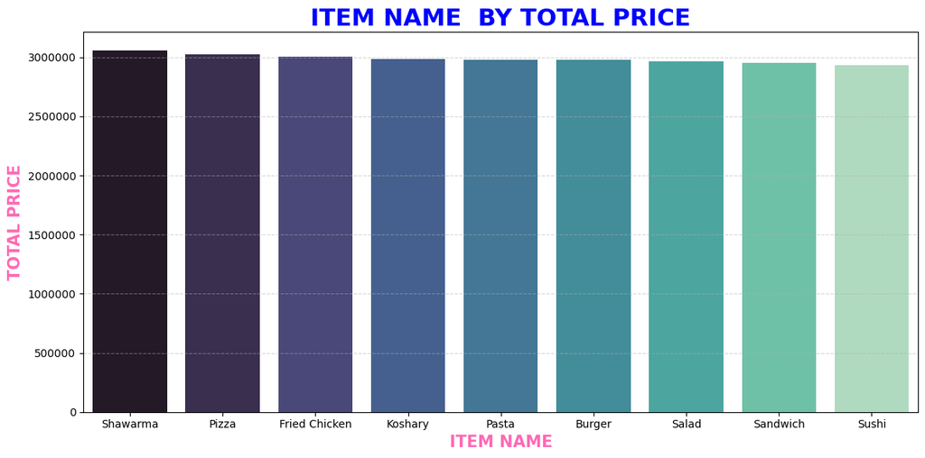

|  | Item_Name | TOTAL_QUANTITY | TOTAL_ORDERS | TOTAL_PRICE |
| --- | --- | --- | --- | --- |
| 0 | Shawarma | 33997 | 11320 | 3060271.73 |
| 1 | Pizza | 33778 | 11230 | 3026674.63 |
| 2 | Fried Chicken | 33428 | 11171 | 3007307.58 |
| 3 | Koshary | 33180 | 11033 | 2984829.23 |
| 4 | Pasta | 32974 | 11077 | 2982339.18 |
| 5 | Burger | 33250 | 11130 | 2978223.72 |
| 6 | Salad | 32820 | 10990 | 2964643.79 |
| 7 | Sandwich | 32920 | 11061 | 2954850.03 |
| 8 | Sushi | 32769 | 10990 | 2933665.72 |

```python
ITEM_NAME = pd.read_sql("""
SELECT Item_Name,
SUM(Quantity) AS TOTAL_QUANTITY,
COUNT(DISTINCT Order_ID) AS TOTAL_ORDERS,
SUM(Total_Price) AS TOTAL_PRICE
FROM Order_delivery
GROUP BY Item_Name
ORDER BY TOTAL_PRICE DESC;
""",engine)
plt.figure(figsize=(12,6))
sns.barplot(data=ITEM_NAME, x="Item_Name", y="TOTAL_PRICE", hue="Item_Name", palette="mako", legend=False)
plt.title("ITEM NAME  BY TOTAL PRICE", fontsize=22, fontweight="bold", color="blue")
plt.xlabel("ITEM NAME", fontsize=15, fontweight="bold", color="hotpink")
plt.ylabel("TOTAL PRICE", fontsize=15, fontweight="bold", color="hotpink")
plt.grid(axis="y", linestyle="--", alpha=0.5)
plt.ticklabel_format(style="plain", axis="y")
plt.tight_layout()
plt.show()
ITEM_NAME
```

```python
pd.read_sql("""
WITH ITEM_NAME AS (SELECT Item_Name, City,
SUM(Total_Price) AS TOTAL_PRICE,
SUM(Quantity) AS TOTAL_QUANTITY,
COUNT(DISTINCT Order_ID) AS TOTAL_ORDERS,
ROW_NUMBER() OVER(PARTITION BY Item_Name ORDER BY SUM(Total_Price) DESC) AS RN
FROM Order_delivery
GROUP BY City, Item_Name)
SELECT Item_Name, City, TOTAL_PRICE, TOTAL_QUANTITY, TOTAL_ORDERS
FROM ITEM_NAME
WHERE RN = 1
ORDER BY TOTAL_PRICE DESC;

""",engine)
```

|  | Item_Name | City | TOTAL_PRICE | TOTAL_QUANTITY | TOTAL_ORDERS |
| --- | --- | --- | --- | --- | --- |
| 0 | Koshary | Assiut | 464059.17 | 5112 | 1677 |
| 1 | Shawarma | Tanta | 459808.11 | 5060 | 1674 |
| 2 | Pizza | Zagazig | 452190.98 | 5017 | 1688 |
| 3 | Salad | Cairo | 450217.93 | 4891 | 1648 |
| 4 | Pasta | Giza | 450108.86 | 4979 | 1680 |
| 5 | Fried Chicken | Tanta | 443920.24 | 4880 | 1585 |
| 6 | Burger | Mansoura | 441530.27 | 4916 | 1632 |
| 7 | Sandwich | Zagazig | 438816.56 | 4963 | 1661 |
| 8 | Sushi | Zagazig | 435210.31 | 4795 | 1597 |

**CITY ANALYSIS**

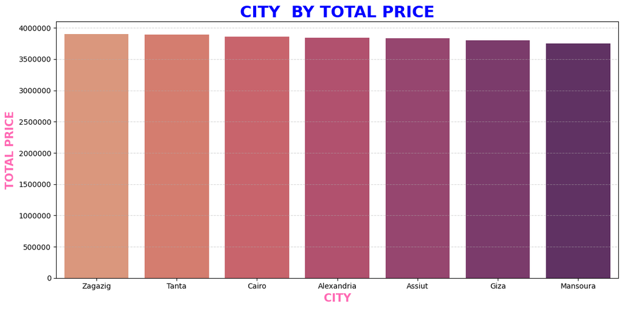

|  | City | TOTAL_QUANTITY | TOTAL_ORDERS | TOTAL_PRICE |
| --- | --- | --- | --- | --- |
| 0 | Zagazig | 43274 | 14538 | 3905102.65 |
| 1 | Tanta | 43202 | 14336 | 3896972.63 |
| 2 | Cairo | 43019 | 14382 | 3856412.50 |
| 3 | Alexandria | 42532 | 14168 | 3841624.98 |
| 4 | Assiut | 42843 | 14302 | 3839095.00 |
| 5 | Giza | 42399 | 14232 | 3798249.80 |
| 6 | Mansoura | 41847 | 14044 | 3755348.05 |

```python
CITY = pd.read_sql("""
SELECT City,
SUM(Quantity) AS TOTAL_QUANTITY,
COUNT(DISTINCT Order_ID) AS TOTAL_ORDERS,
SUM(Total_Price) AS TOTAL_PRICE
FROM Order_delivery
GROUP BY City
ORDER BY TOTAL_PRICE DESC;
""",engine)
plt.figure(figsize=(12,6))
sns.barplot(data=CITY, x="City", y="TOTAL_PRICE", hue="City", palette="flare", legend=False)
plt.title("CITY  BY TOTAL PRICE", fontsize=22, fontweight="bold", color="blue")
plt.xlabel("CITY", fontsize=15, fontweight="bold", color="hotpink")
plt.ylabel("TOTAL PRICE", fontsize=15, fontweight="bold", color="hotpink")
plt.grid(axis="y", linestyle="--", alpha=0.5)
plt.ticklabel_format(style="plain", axis="y")
plt.tight_layout()
plt.show()
CITY
```

```python
pd.read_sql("""
WITH CITY AS (SELECT Item_Name, City,
SUM(Total_Price) AS TOTAL_PRICE,
SUM(Quantity) AS TOTAL_QUANTITY,
COUNT(DISTINCT Order_ID) AS TOTAL_ORDERS,
ROW_NUMBER() OVER(PARTITION BY City ORDER BY SUM(Total_Price) DESC) AS RN
FROM Order_delivery
GROUP BY City, Item_Name)
SELECT City, Item_Name, TOTAL_PRICE, TOTAL_QUANTITY, TOTAL_ORDERS
FROM CITY
WHERE RN = 1
ORDER BY TOTAL_PRICE DESC;

""",engine)
```

|  | City | Item_Name | TOTAL_PRICE | TOTAL_QUANTITY | TOTAL_ORDERS |
| --- | --- | --- | --- | --- | --- |
| 0 | Assiut | Koshary | 464059.17 | 5112 | 1677 |
| 1 | Tanta | Shawarma | 459808.11 | 5060 | 1674 |
| 2 | Cairo | Shawarma | 457394.82 | 5095 | 1672 |
| 3 | Zagazig | Pizza | 452190.98 | 5017 | 1688 |
| 4 | Giza | Pasta | 450108.86 | 4979 | 1680 |
| 5 | Mansoura | Burger | 441530.27 | 4916 | 1632 |
| 6 | Alexandria | Burger | 438735.85 | 4927 | 1602 |

```python
pd.read_sql("""
SELECT City,
COUNT(*) AS TOTAL_ORDERS,
SUM(CASE WHEN Order_Status = 'Delivered'  THEN 1 ELSE 0 END) AS DELIVERED,
SUM(CASE WHEN Order_Status = 'Cancelled'  THEN 1 ELSE 0 END) AS CANCELLED,
SUM(CASE WHEN Order_Status = 'In Transit' THEN 1 ELSE 0 END) AS IN_TRANSIT,
ROUND(100.0 * SUM(CASE WHEN Order_Status = 'Cancelled' THEN 1 ELSE 0 END) / COUNT(*), 2) AS CANCELLATION_RATE_PCT,
SUM(CASE WHEN Order_Status = 'Delivered' THEN Total_Price ELSE 0 END) AS DELIVERED_REVENUE,
SUM(CASE WHEN Order_Status = 'Cancelled' THEN Total_Price ELSE 0 END) AS LOST_REVENUE
FROM Order_delivery
GROUP BY City
ORDER BY DELIVERED_REVENUE DESC;
""", engine)
```

|  | City | TOTAL_ORDERS | DELIVERED | CANCELLED | IN_TRANSIT | CANCELLATION_RATE_PCT | DELIVERED_REVENUE | LOST_REVENUE |
| --- | --- | --- | --- | --- | --- | --- | --- | --- |
| 0 | Zagazig | 14538 | 12450 | 1351 | 737 | 9.29 | 3335237.33 | 366864.05 |
| 1 | Tanta | 14336 | 12132 | 1458 | 746 | 10.17 | 3298463.89 | 392902.55 |
| 2 | Assiut | 14302 | 12220 | 1384 | 698 | 9.68 | 3291796.90 | 366592.17 |
| 3 | Alexandria | 14168 | 12111 | 1334 | 723 | 9.42 | 3287558.43 | 349145.82 |
| 4 | Cairo | 14382 | 12246 | 1411 | 725 | 9.81 | 3285382.34 | 375762.25 |
| 5 | Giza | 14232 | 12094 | 1461 | 677 | 10.27 | 3226574.87 | 387810.12 |
| 6 | Mansoura | 14044 | 11946 | 1413 | 685 | 10.06 | 3192601.37 | 377628.95 |

**DAILY ANALYSIS**

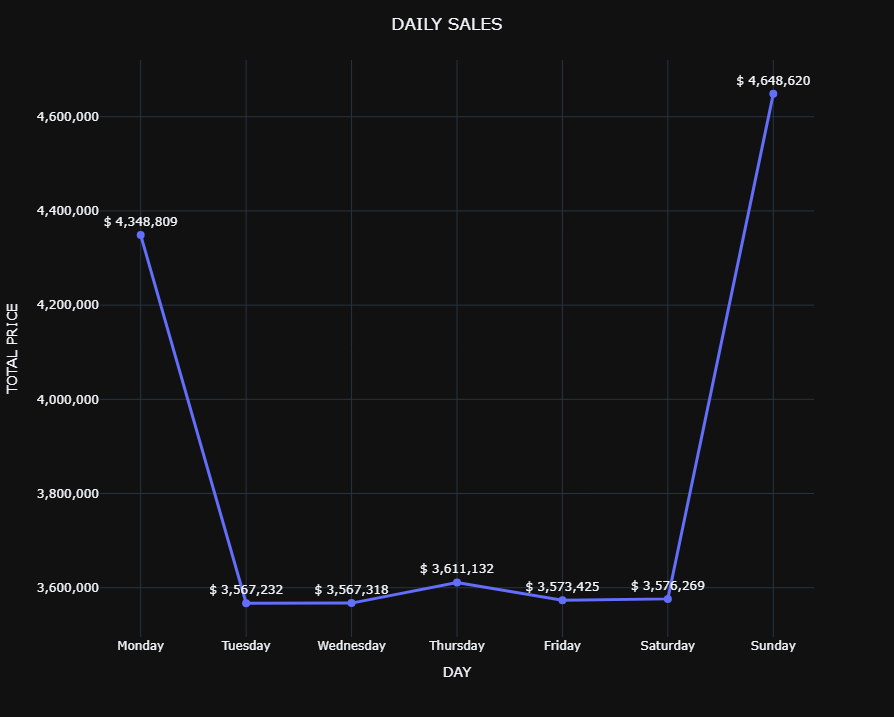

|  | DAY_NAME | TOTAL_ORDERS | TOTAL_QUANTITY | TOTAL_PRICE |
| --- | --- | --- | --- | --- |
| 0 | Monday | 16136 | 48415 | 4348809.26 |
| 1 | Tuesday | 13341 | 39782 | 3567232.43 |
| 2 | Wednesday | 13284 | 39628 | 3567318.11 |
| 3 | Thursday | 13371 | 39775 | 3611132.34 |
| 4 | Friday | 13245 | 39869 | 3573424.57 |
| 5 | Saturday | 13306 | 39889 | 3576269.39 |
| 6 | Sunday | 17319 | 51758 | 4648619.51 |

```python
DAY = pd.read_sql("""
SELECT DAY_NAME,
COUNT(*) AS TOTAL_ORDERS,
SUM(Quantity) AS TOTAL_QUANTITY,
SUM(Total_Price) AS TOTAL_PRICE
FROM Order_delivery

GROUP BY DAY_NAME
ORDER BY
CASE DAY_NAME
WHEN 'Monday' THEN 1
WHEN 'Tuesday' THEN 2
WHEN 'Wednesday' THEN 3
WHEN 'Thursday' THEN 4
WHEN 'Friday' THEN 5
WHEN 'Saturday' THEN 6
WHEN 'Sunday' THEN 7
    END;
""", engine)

fig = px.line(DAY, x="DAY_NAME", y="TOTAL_PRICE", markers=True, text="TOTAL_PRICE")

fig.update_traces(texttemplate="$ %{text:,.0f}", textposition="top center", line=dict(width=3), marker=dict(size=8))
fig.update_layout(title="DAILY SALES", title_x=0.5, height=700, width=1100, xaxis_title="DAY", yaxis_title="TOTAL PRICE", hovermode="x unified",
template="plotly_dark")
fig.update_yaxes(tickformat=",")

fig.show()
DAY
```

**TRAFFIC LEVEL ANALYSIS**

```python
pd.read_sql("""
SELECT Traffic_Level,
SUM(Total_Price) AS TOTAL_PRICE,
SUM(Quantity) AS TOTAL_QUANTITY,
COUNT(Order_ID) AS ORDERS
FROM Order_delivery
GROUP BY Traffic_Level
ORDER BY TOTAL_PRICE DESC;
""",engine)
```

|  | Traffic_Level | TOTAL_PRICE | TOTAL_QUANTITY | ORDERS |
| --- | --- | --- | --- | --- |
| 0 | Low | 12327851.09 | 136807 | 45826 |
| 1 | High | 7842215.09 | 87491 | 29221 |
| 2 | Medium | 6722739.43 | 74818 | 24955 |

```python
pd.read_sql("""
SELECT Traffic_Level,
COUNT(*) AS TOTAL_ORDERS,
ROUND(100.0 * COUNT(*) / SUM(COUNT(*)) OVER (), 2) AS PCT_OF_ORDERS,
SUM(CASE WHEN Order_Status = 'Cancelled' THEN 1 ELSE 0 END) AS CANCELLED,
ROUND(100.0 * SUM(CASE WHEN Order_Status = 'Cancelled' THEN 1 ELSE 0 END) / COUNT(*), 2) AS CANCELLATION_RATE_PCT,
ROUND(AVG(Delivery_Duration_Minutes * 1.0), 2) AS AVG_DELIVERY_MIN,
ROUND(AVG(Delivery_Distance_km), 2) AS AVG_DISTANCE_KM,
SUM(CASE WHEN Order_Status = 'Delivered' THEN Total_Price ELSE 0 END) AS DELIVERED_REVENUE
FROM Order_delivery
GROUP BY Traffic_Level
ORDER BY CASE Traffic_Level WHEN 'Low' THEN 1 WHEN 'Medium' THEN 2 WHEN 'High' THEN 3 END;
""", engine)
```

|  | Traffic_Level | TOTAL_ORDERS | PCT_OF_ORDERS | CANCELLED | CANCELLATION_RATE_PCT | AVG_DELIVERY_MIN | AVG_DISTANCE_KM | DELIVERED_REVENUE |
| --- | --- | --- | --- | --- | --- | --- | --- | --- |
| 0 | Low | 45826 | 45.83 | 4563 | 9.96 | 37.58 | 2.16 | 10497719.49 |
| 1 | Medium | 24955 | 24.95 | 2394 | 9.59 | 37.49 | 2.17 | 5761009.51 |
| 2 | High | 29221 | 29.22 | 2855 | 9.77 | 37.45 | 2.16 | 6658886.13 |

**DRIVER AVAILABILITY ANALYSIS**

```python
pd.read_sql("""
SELECT Driver_Availability,
COUNT(*) AS TOTAL_ORDERS,
ROUND(100.0 * COUNT(*) / SUM(COUNT(*)) OVER (), 2) AS PCT_OF_ORDERS,
SUM(CASE WHEN Order_Status = 'Cancelled' THEN 1 ELSE 0 END) AS CANCELLED,
ROUND(100.0 * SUM(CASE WHEN Order_Status = 'Cancelled' THEN 1 ELSE 0 END) / COUNT(*), 2) AS CANCELLATION_RATE_PCT,
ROUND(AVG(Delivery_Duration_Minutes * 1.0), 2) AS AVG_DELIVERY_MIN,
ROUND(AVG(Delivery_Distance_km), 2) AS AVG_DISTANCE_KM,
SUM(CASE WHEN Order_Status = 'Delivered' THEN Total_Price ELSE 0 END) AS DELIVERED_REVENUE
FROM Order_delivery
GROUP BY Driver_Availability
ORDER BY Driver_Availability DESC;
""", engine)
```

|  | Driver_Availability | TOTAL_ORDERS | PCT_OF_ORDERS | CANCELLED | CANCELLATION_RATE_PCT | AVG_DELIVERY_MIN | AVG_DISTANCE_KM | DELIVERED_REVENUE |
| --- | --- | --- | --- | --- | --- | --- | --- | --- |
| 0 | Online | 90113 | 90.11 | 8823 | 9.79 | 37.53 | 2.17 | 20651887.53 |
| 1 | Offline | 9889 | 9.89 | 989 | 10.00 | 37.47 | 2.16 | 2265727.60 |

**PAYMENT METHOD ANALYSIS**

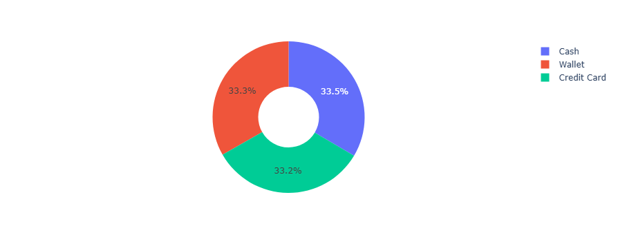

|  | Payment_Method | TOTAL_PRICE | TOTAL_QUANTITY | ORDERS |
| --- | --- | --- | --- | --- |
| 0 | Credit Card | 8938782.35 | 99443 | 33223 |
| 1 | Wallet | 8943906.18 | 99614 | 33251 |
| 2 | Cash | 9010117.08 | 100059 | 33528 |

```python
PAYMENT_METHOD = pd.read_sql("""
SELECT Payment_Method,
SUM(Total_Price) AS TOTAL_PRICE,
SUM(Quantity) AS TOTAL_QUANTITY,
COUNT(Order_ID) AS ORDERS
FROM Order_delivery
GROUP BY Payment_Method
ORDER BY TOTAL_PRICE;
""",engine)
fig = px.pie(PAYMENT_METHOD, names="Payment_Method", values="TOTAL_PRICE", hole=0.4)
fig.show()
PAYMENT_METHOD
```

**ORDER STATUS ANALYSIS**

```python
pd.read_sql("""
SELECT Order_Status,
SUM(Total_price) AS TOTAL_PRICE,
SUM(Quantity) AS TOTAL_QUANTITY,
COUNT(*) AS TOTAL_ORDERS
FROM Order_delivery
GROUP BY Order_Status
ORDER BY TOTAL_PRICE DESC;

""",engine)
```

|  | Order_Status | TOTAL_PRICE | TOTAL_QUANTITY | TOTAL_ORDERS |
| --- | --- | --- | --- | --- |
| 0 | Delivered | 22917615.13 | 254742 | 85199 |
| 1 | Cancelled | 2616705.91 | 29343 | 9812 |
| 2 | In Transit | 1358484.57 | 15031 | 4991 |

**HOURLY ANALYSIS**

```python
pd.read_sql("""
SELECT
DATEPART(HOUR, TRY_CONVERT(DATETIME, Order_Time, 105)) AS ORDER_HOUR,
COUNT(DISTINCT Order_ID)  AS TOTAL_ORDERS,
SUM(Total_Price) AS DELIVERED_REVENUE
FROM Order_delivery
WHERE Order_Status = 'Delivered'
AND TRY_CONVERT(DATETIME, Order_Time, 105) IS NOT NULL
GROUP BY DATEPART(HOUR, TRY_CONVERT(DATETIME, Order_Time, 105))
ORDER BY ORDER_HOUR;

""",engine)
```

|  | ORDER_HOUR | TOTAL_ORDERS | DELIVERED_REVENUE |
| --- | --- | --- | --- |
| 0 | 0 | 3539 | 933372.73 |
| 1 | 1 | 3635 | 984493.77 |
| 2 | 2 | 3602 | 957554.79 |
| 3 | 3 | 3539 | 978475.71 |
| 4 | 4 | 3599 | 960480.10 |
| 5 | 5 | 3467 | 918100.06 |
| 6 | 6 | 3509 | 960926.84 |
| 7 | 7 | 3585 | 959193.69 |
| 8 | 8 | 3539 | 951706.45 |
| 9 | 9 | 3528 | 940658.43 |
| 10 | 10 | 3547 | 966484.46 |
| 11 | 11 | 3602 | 961449.24 |
| 12 | 12 | 3535 | 947369.60 |
| 13 | 13 | 3420 | 928377.32 |
| 14 | 14 | 3623 | 981546.27 |
| 15 | 15 | 3618 | 975782.62 |
| 16 | 16 | 3600 | 967164.36 |
| 17 | 17 | 3529 | 948872.33 |
| 18 | 18 | 3582 | 955175.13 |
| 19 | 19 | 3487 | 936115.74 |
| 20 | 20 | 3489 | 938280.53 |
| 21 | 21 | 3497 | 939216.75 |
| 22 | 22 | 3530 | 953108.10 |
| 23 | 23 | 3598 | 973710.11 |

**ORDER DATE ANALYSIS**

```python
pd.read_sql("""

SELECT
CAST(TRY_CONVERT(DATETIME, Order_Time, 105) AS DATE) AS ORDER_DATE,
COUNT(*)   AS TOTAL_ORDERS,
SUM(Total_Price) AS DELIVERED_REVENUE
FROM Order_delivery
WHERE Order_Status = 'Delivered'
AND TRY_CONVERT(DATETIME, Order_Time, 105) IS NOT NULL
GROUP BY CAST(TRY_CONVERT(DATETIME, Order_Time, 105) AS DATE)
ORDER BY ORDER_DATE;

""",engine)
```

|  | ORDER_DATE | TOTAL_ORDERS | DELIVERED_REVENUE |
| --- | --- | --- | --- |
| 0 | 2025-06-01 | 3311 | 908670.61 |
| 1 | 2025-06-02 | 5708 | 1553013.18 |
| 2 | 2025-06-03 | 5651 | 1499492.29 |
| 3 | 2025-06-04 | 5678 | 1527330.18 |
| 4 | 2025-06-05 | 5721 | 1545452.54 |
| 5 | 2025-06-06 | 5638 | 1519297.81 |
| 6 | 2025-06-07 | 5763 | 1545172.76 |
| 7 | 2025-06-08 | 5713 | 1511345.84 |
| 8 | 2025-06-09 | 5643 | 1517049.84 |
| 9 | 2025-06-10 | 5681 | 1529644.19 |
| 10 | 2025-06-11 | 5618 | 1513243.07 |
| 11 | 2025-06-12 | 5688 | 1534898.42 |
| 12 | 2025-06-13 | 5698 | 1540001.42 |
| 13 | 2025-06-14 | 5605 | 1510232.14 |
| 14 | 2025-06-15 | 5700 | 1534021.53 |
| 15 | 2025-06-16 | 2383 | 628749.31 |

## Conclusion

### 1. Cancellations are the biggest loss

85.2% of orders were delivered (22.92M), 9.8% were cancelled (2.62M) and 5.0% were still in transit (1.36M). About 1 in 10 orders is cancelled.

### 2. Traffic and driver availability do not explain the cancellations

- Cancellation is 9.6-10.0% across low, medium and high traffic.
- It is 9.8% with online drivers and 10.0% with offline drivers.
- Average delivery time is about 37.5 minutes in every traffic level and for both driver states.

Neither factor drives cancellations or delivery time in this data, so the cause must be somewhere else.

### 3. Cities, items and payment methods are almost evenly split

- Zagazig leads on revenue (3.91M) and Mansoura is last (3.76M), a gap of about 4%.
- Shawarma is the top item (3.06M, about 11% of revenue) and Sushi is last (2.93M), also about a 4% gap.
- Cash, wallet and credit card each carry about one third of revenue (spread under 1%).
- Cancellation by city ranges from 9.3% (Zagazig) to 10.3% (Giza). Giza, Tanta and Mansoura are slightly above 10%.

These gaps are small and were not statistically tested, so no city, item or payment method clearly outperforms the others.

### 4. Demand is flat over time

- Delivered orders are about 3,550 per hour (range 3,420-3,635), with no lunch or dinner peak, and about 5,700 per full day.
- The Sunday/Monday are highest "spikes".

### 5. Offline-driver orders need an explanation

About 9.9% of orders (9,889) are linked to drivers marked Offline, and they still have normal delivery times. This probably means availability was recorded after the order, not at order time.

## Recommendations

1. **Find the real cause of cancellations.** Traffic and driver availability are ruled out. Test vehicle type, delivery distance, restaurant and item next. Cutting cancellations by 2 percentage points would recover about 0.5M.
2. **Clarify what `Driver_Availability` means.** Check when it is recorded before using it for driver planning, since offline drivers are completing orders normally.
3. **Don't act on 4% gaps.** City, item and payment differences are small. Run a significance test (for example chi-square on cancellation rate by city) or collect more data before reallocating inventory, drivers or marketing.
4. **Review Giza, Tanta and Mansoura.** They have the highest cancellation rates (above 10%), but the differences are small, so confirm with a test first.
5. **Collect a longer period.** Two weeks can't show weekly, monthly or seasonal patterns. Use at least three months.
6. **Report revenue on delivered orders only.** Show cancelled and in-transit value as separate lines so headline revenue isn't overstated.

## Limitations

The data covers only 1-16 June 2025, with partial first and last days, and looks synthetic. The analysis shows associations, not causes. Average delivery time includes all order statuses, so it should be recalculated for delivered orders only before it is used for decisions.